# 508HW1

Grace Falken

April 06, 2022

## Introduction to the Data

The `swiss` dataset presents fertility and economic indicators of 47 Swiss provinces in 1888. For each province, we observe fertility, which ranges from 35 to 92; the percent occupational involvement agriculture; passage rates of an army examination; population percentage with education beyond primary school; percent Catholic; and infant mortality rates.

First, it’s helpful to know the range and distribution of these variables:

| Fertility | Agriculture | Examination | Education | Catholic | Infant.Mortality |
| --- | --- | --- | --- | --- | --- |
| Min. :35.00 | Min. : 1.20 | Min. : 3.00 | Min. : 1.00 | Min. : 2.150 | Min. :10.80 |
| 1st Qu.:64.70 | 1st Qu.:35.90 | 1st Qu.:12.00 | 1st Qu.: 6.00 | 1st Qu.: 5.195 | 1st Qu.:18.15 |
| Median :70.40 | Median :54.10 | Median :16.00 | Median : 8.00 | Median : 15.140 | Median :20.00 |
| Mean :70.14 | Mean :50.66 | Mean :16.49 | Mean :10.98 | Mean : 41.144 | Mean :19.94 |
| 3rd Qu.:78.45 | 3rd Qu.:67.65 | 3rd Qu.:22.00 | 3rd Qu.:12.00 | 3rd Qu.: 93.125 | 3rd Qu.:21.70 |
| Max. :92.50 | Max. :89.70 | Max. :37.00 | Max. :53.00 | Max. :100.000 | Max. :26.60 |

It’s also helpful to observe how these variables are generally related:

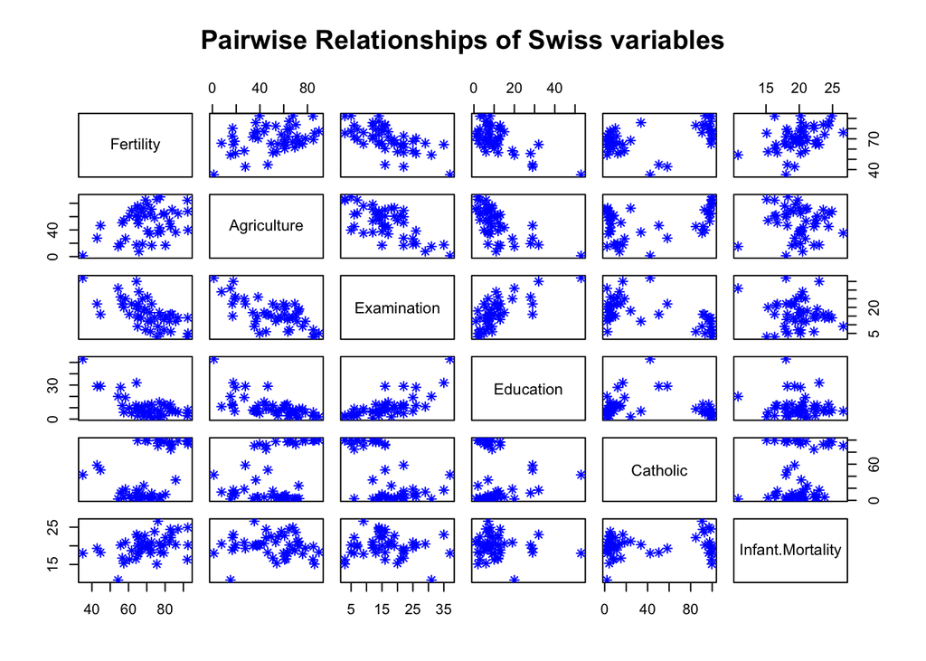

## Relating Agriculture and Education

Let’s say we’re particularly interested in the relationship between the percent of the population in the agricultural industry. The correlation between these two variables is -0.687, which is relatively high. As a point of comparison, the correlation between how much of the population is Catholic and the portion of the population working in agriculture is 0.401.

We can also looks at this in more detail:

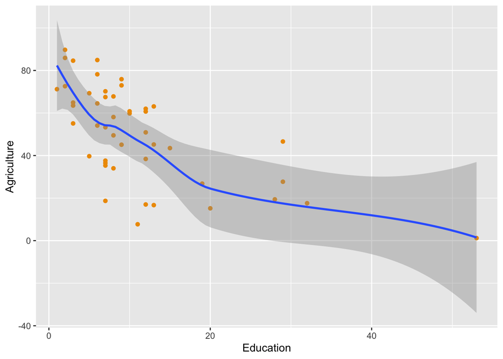

And notice that these variables are more tightly related (smaller standard errors) when the population portion with education beyond primary school is below twenty percent.